# Wie insolvenzgefährdet sind Unternehmen?

Modellanalyse und Prognose anhand von Controlling-Kennzahlen

# Motivation

In diesem Projekt sollen Sie die Insolvenz- bzw. Ausfallwahrscheinlichkeiten von Unternehmen anhand deren Kennzahlen zur Vermögens-, Finanz- und Ertragslage mittels Diskriminanzanalyse untersuchen und prognostizieren. Dies ist insbesondere wichtig, wenn Sie im Risikomanagement einer Firma arbeiten und potentielle Übernahmekandidaten oder Investitionsmöglichkeiten ausfindig machen sollen.

Die Diskriminanzanalyse basiert auf statistischen Methoden, die u.a. von Altman (1968) im betriebswirtschaftlichem Kontext zur Insolvenzprognose verwendet werden und bis in die heutige Zeit gängige Verfahren darstellen. Mit Hilfe dieser Analyse soll die Frage beantwortet werden, ob sich zwei Gruppen (in diesem Fall solvente und insolvente Unternehmen) signifikant voneinander unterscheiden. Weiterhin können sich damit die Gruppenunterschiede erklären lassen und es kann untersucht werden, wie ein Unternehmen anhand bestimmter Kennzahlen von einem solchen Modell klassifiziert würde, wenn die Gruppenzugehörigkeit unbekannt ist. Insbesondere Kennzahlen aus dem Controlling eignen sich gut für eine solche Klassifikation. Die lineare Diskriminanzanalyse, welche Sie in diesem Projekt anwenden ist auch häufig bei Klassifikationsproblemen im maschinellen Lernen anzutreffen.

# Daten

## Datenaufbereitung

1. In dem Ordner “data” finden Sie die Excel Datei “Diskriminanzanalyse.xlsx” mit Kennzahlen zur Vermögens- und Ertragslage für Unternehmen aus dem Bereich “Hersteller von Nahrungsmitteln”. Der Datensatz stammt aus Datastream und beinhaltet alle Unternehmen weltweit aus diesem Bereich die in Dollar gehandelt werden. Es werden sowohl solvente (im Datenblatt “Active”), als auch insolvente (im Datenblatt “Dead”) Unternehmen gelistet.
- Lesen Sie die Daten aus dem Excel-Sheet “Active” ein und speichern diese als Datensatz `solvent` ab. Für die insolventen Unternehmen lesen Sie das Excel-Sheet “Dead” ein uns speichern diese als Datensatz `insolvent` ab.
- Für einige Unternehmen konnten keine Werte in Datastream gefunden werden, diese haben in der Spalte `Name` den Namen “#ERROR” bzw. in der Spalte `Code` ein *NA*
  - Entfernen Sie diese Zeilen aus ihrem Datensatz

*Hinweis:* Datastream ist eine Datenbank, die Kennzahlen zur Finanzlage von börsennotierten Unternehmen weltweit beinhaltet. Die Lizenzen zu Datastream an der Universität Ulm werden von der Studienkommission Wirtschaftswissenschaften und der LBBW bezahlt und die Datenbank steht allen WiWi-Studierenden frei zur Verfügung. [Nähere Informationen zu Datastream finden Sie hier](https://www.uni-ulm.de/mawi/strategische-unternehmensfuehrung-und-finanzierung/menu-item/datastream-and-eikon/) (Bitte beachten: Sie müssen im Uninetz (z.B. über VPN) eingeloggt sein um die Informationen zu sehen).

2. Nun haben Sie die Daten in R eingelesen. Jedoch müssen Sie diese noch weiter aufarbeiten um damit später arbeiten zu können:
- Generieren Sie sich eine neue Spalte `variable`, welche den in der Spalte `Code` in Klammern befindlichen Ausdruck beinhaltet (bspw. WC02999)
- Generieren Sie sich eine neue Spalte `dscode`, welche die in der Spalte `Code` befindliche Zahlen/Buchstaben/Sonderzeichen Kombination **ohne die Klammern und deren Inhalt** beinhaltet (bspw. U:HRL)
- Generieren Sie sich eine neue Spalte `firm_name`, welche den in der Spalte `Name` befindlichen Namen der Firma, **ohne** die Bezeichnung für die Variable enthält, d.h. alles vor dem `-`
- Generieren Sie sich eine neue Spalte `variable_name`, welche den in der Spalte `Name` befindliche Bezeichnung für die Variable enthält, d.h. alle Elemente nach `-`

*Hinweis:* Laden Sie das Paket `stringr` und machen sich mit der Funktion `str_extract()` vertraut. Es ist hilfreich sich die [kurze Einführung in reguläre Ausdrücke mit stringr](https://stringr.tidyverse.org/articles/regular-expressions.html) anzuschauen!

Quellen: https://www.youtube.com/watch?v=PcUJXrN-C_E https://de.codeflow.site/questions/9796752/extracting-number-and-name-from-string-r

3. Die Daten, welche wir ihnen aus Datastream heruntergeladen haben, sind im wide-Format abgespeichert. Um mit diesen Daten innerhalb des `tidyverse` sinnvoll arbeiten zu können sollten Sie ihre Datensätze `solvent` und `insolvent` noch in das`long`-Format überführen.
- Erzeugen Sie eine Indikator-Variable (häufig auch Dummy-Variable genannt) `default`, welche 1 ist falls eine Firma insolvent ist und 0 falls diese solvent ist.
- Formatieren Sie die Ausprägung aller Variablen zu nummerischen Werten um. Dies ist nötig um später Berechnungen auf diesen Variablen durchführen zu können.
- Schließlich sollten Sie die zwei Datensätze `solvent` und `insolvent` zu einem Datensatz zusammenführen, welchen Sie bitte `firms_total` nennen. Diesen Datensatz sollten Sie nun so umformen, dass jede Variable eine eigene Spalte besitzt (siehe Hinweis 2)

*Hinweis 1:* Ein Beispiel wie Daten vom wide-Formt ins long-Format zu überführen sind sehen Sie in der [Case-Study Teil 1](https://projektkurs-data-science-ulm2021.netlify.app/case-study/case_study_germany_1.html)

*Hinweis 2:* Stellen Sie sicher, dass jede Variable in ihrem Datensatz `firms_total` eine eigene Spalte besitzt und nach dem Namen (z.B. “Total Assets”) benannt ist (schauen Sie sich hierzu `pivot_wider()` näher an). Hier die ersten zwei Zeilen wie der fertige Datensatz `firms_total` aussehen sollte als Beispiel:

| dscode | firm_name | jahr | default | TOTAL ASSETS | RETAINED EARNINGS | WORKING CAPITAL |
| --- | --- | --- | --- | --- | --- | --- |
| U:HRL | HORMEL FOODS CORP | 1990 | 0 | 799422 | 503852 | 293818 |
| U:HRL | HORMEL FOODS CORP | 1991 | 0 | 856835 | 570698 | 346164 |

Da wir sehr viele Unternehmen in unserem Datensatz haben, welche noch aktiv am Markt als “Hersteller von Nahrungsmitteln” mitmischen und nur sehr wenige, welche in der Zeit seit 1990 insolvent gegangen sind, wäre es durchaus denkbar das in unserem Datensatz speziell nur kleine Unternehmen insolvent gegangen sind. Daher sollten wir bei den noch solventen Unternehmen auf solche einschränken, die mit unseren insolventen Unternehmen bzgl. ihrer Größe vergleichbar sind. Weiterhin haben wir hier Paneldaten gegeben, doch für die Berechnung, die wir durchführen möchten, reichen uns Querschnittsdaten aus dem Jahr vor der Insolvenz der Firma, bzw. aus dem Jahr 2019 für noch am Markt befindliche Unternehmen aus. Daher sollten wir noch die folgenden Schritte tätigen:

4. Erstellen Sie einen neuen Datensatz, welchen Sie `calculations` nennen. In diesem Datensatz sollte nur noch eine Beobachtung pro Firma abgespeichert sein:
- Für *insolvente* Unternehmen: Die letzte Beobachtung vor der Insolvenz einer Firma aus dem Datensatz `firms_total` (d.h. die Beobachtung aus dem Jahr vor der Insolvenz)
- Für *solvente* Unternehmen: Die Beobachtung aus dem Jahr 2019 aus dem Datensatz `firms_total`.

*Hinweis:* Sie können davon ausgehen das die Firma in ihrem Datensatz dann insolvent ist, wenn der Dummy `default == 1` und wenn in den “Total Assets” nur noch `NA` eingetragen ist.

5. Erstellen Sie eine Tabelle in der Sie die Anzahl an Beobachtungen, den Mittelwert, die Standardabweichung, sowie das Minimum und Maximum der Variable “Total Assets” getrennt für alle solventen und insolventen Unternehmen in ihrem Datensatz `calculations` darstellen:
- Betrachten Sie **nur** Unternehmen deren **“Total Assets” größer Null** sind und deren **“Retained Earnings” und “Working Capital” verfügbar** sind

Beschreiben und interpretieren Sie ihre Tabelle!

Informationen zu den TOTAL ASSETS von solventen und insolventen Unternehmen

| Status | Anzahl der Unternehmen | Mittelwert | Standardabweichung | Minimum | Maximum |
| --- | --- | --- | --- | --- | --- |
| solvent | 102 | 5652776 | 14130370 | 1 | 101450000 |
| insolvent | 45 | 1689473 | 3920872 | 149 | 22947000 |

In der Tabelle sehen wir zu allen insolventen und allen solventen Unternehmen die Anzahl an Unternehmen, den Mittelwert, die Standardabweichung, das Minimum und das Maximum der TOTAL ASSETS. Bei solventen Unternehmen beschränken sich die Daten auf Zahlen aus dem Jahr 2019 und bei den insolventen auf das Jahr vor der Insolvenz.

Es fällt auf, dass es in dem Datensatz mehr solvente, als insolvente Unternehmen gibt. Auch der Mittelwert der TOTAL ASSETS ist bei diesen höher als bei den insolventen. Dies liegt vermutlich daran, dass diese im Jahr vor der Insolvenz schon mit wirtschaftlichen Problemen zu kämpfen hatten und deswegen die Bilanzsumme (TOTAL ASSETS) schon sehr niedrig war. Dies könnte daran liegen, da man, um die Insolvenz zu verhindern, eventuell schon Sachanlagen verkaufen musste. Die Standardabweichung ist bei den solventen Unternehmen ebenfalls höher, was daran liegt, dass es hier neben den durchschnittlichen Unternehmen auch einige große und kleine gibt. Dadurch ist die Standardabweichung höher, als wenn die Masse der Unternehmen alle ungefähr dieselben TOTAL ASSETS haben. Bei den insolventen Unternehmen geht es den meisten ungefähr gleich schlecht, da sie vor der Pleite stehen. Somit unterscheiden sich die Bilanzsummen nicht so stark untereinander wie bei den solventen Unternehmen, obwohl 3920872 trotzdem nicht zu vernachlässigen ist. Beim Minimum ist auffällig, dass dieses bei den solventen Unternehmen bei 1 liegt und bei den insolventen bei 149. Ein Unternehmen mit Bilanzsumme 1 kann nicht wirklich real existieren, außer als Briefkastenfirma, welche nichts herstellt. Dies kann jedoch nicht der Fall sein, da es sich bei allen Unternehmen in diesem Datensatz um “Hersteller von Nahrungsmitteln” handelt. Deswegen gehen wir hier von einem Fehler aus. Das Maximum ist, wie zu erwarten, bei den solventen Unternehmen größer, da die Bilanzsumme bei solventen im Regelfall größer ist als die bei Unternehmen kurz vor der Insolvenz. Deswegen sollte dies auch auf das Maximum zutreffen.

6. Schränken Sie ihren Datensatz `calculations` auf Unternehmen ein, welche ein “Total Asset” zwischen 0 und 23 Mio. Dollar haben.
- Betrachten Sie **nur** Unternehmen deren **“Total Assets” größer Null** sind und deren **“Retained Earnings” und “Working Capital” verfügbar** sind
  - Generieren Sie weiterhin die folgenden finanziellen Ratios:

$$Ratio_1 = Working\ Capital / Total\ Assets$$
$$Ratio_2 = Retained\ Earnings / Total\ Assets$$

*Hinweis:* Sie sollten nun 95 solvente und 45 insolvente Unternehmen in ihrem Datensatz haben

7. Erstellen Sie eine Tabelle in der Sie die durchschnittliche $Ratio_1$ und $Ratio_2$ der solventen und insolventen Unternehmen einander gegenüberstellen.
- Welche Erkenntnisse erhalten Sie aus dieser Tabelle?
  - Was sagen die Ratios aus?

Beschreiben und interpretieren Sie ihre Tabelle.

Informationen zur Ratio1 und Ratio2 bei solventen und insolventen Unternehmen

| Status | Durchschnittliche Ratio1 | Durchschnittliche Ratio2 |
| --- | --- | --- |
| insolvent | -0.03 | -2.47 |
| solvent | -5.59 | -278.74 |

In der Tabelle sehen wir für solvente Unternehmen aus dem Jahr 2019 und für insolvente Unternehmen aus dem letzten Jahr vor ihrer Insolvenz die durchschnittliche Ratio1 (Working Capital / Total Assets) und durchschnittliche Ratio2 (Retained Earnings / Total Assets).

Bei Ratio1 sehen wir, dass diese im Durchschnitt bei den solventen Unternehmen mit -5.59 niedriger ist als bei den insolventen mit -0.03. Diese Kennzahl sagt den Anteil des Working Capital, also des Nettoumlaufvermögens an den Total Assets, also an der Bilanzsumme aus. Da die Bilanzsumme nicht negativ sein kann (Bedingung oben), bedeutet das, dass das Nettoumlaufvermögen bei solventen und bei insolventen Unternehmen in den betrachteten Jahren im Schnitt negativ ist. Das Nettoumlaufvermögen setzt sich wiederum aus Umlaufvermögen - kurzfristiges Fremdkapital (Verbindlichkeiten) zusammen. Ein negativer Wert hier bedeutet, dass das Unternehmen mehr kurzfr. Fremdkapital als Umlaufvermögen hat, also die Lieferanten die Umsätze sozusagen vorfinanzieren. Eine Ratio1 von -0.03, also nahe 0 bedeutet somit, dass das Nettoumlaufvermögen auch nahe 0 ist. Dies ist eher unwahrscheinlich, da somit Umlaufvermögen und kurzfristiges Fremdkapital genau gleich sein müssten. Es handelt sich hier lediglich um einen Mittelwert. Der Wert -5.59 macht jedoch auch keinen Sinn, da somit die Total Assets negativ und 5-mal so groß wie die Bilanzsumme sein müssten. Hier handelt es sich um eine Verfälschung durch einzelne Unternehmen mit falschen Angaben, wie z.B. bei der Firma “WORLD HEALTH”, mit einer Bilanzsumme von 1. Wir haben daraufhin den Median dieser Kennzahl (Ratio1) ausgerechnet und kamen bei solventen Unternehmen auf 0.11 und bei den insolventen auf 0.13. Diese beiden Werte ergeben mehr Sinn und spiegeln mehr die breite Masse der Unternehmen wider, da sie nicht wie der Durchschnitt durch Extrema beeinflusst sind. Hieran erkennt man also, dass insolvente Unternehmen einen etwas höheren Anteil an Nettoumlaufvermögen an der Bilanzsumme haben. Dies kann man vermutlich wiederum damit erklären, dass diese weniger kurzfristiges Fremdkapital besitzen, eventuell verursacht durch weniger Aufträge als solvente Unternehmen.

Bei Ratio2 sehen wir, dass diese im Durchschnitt bei den solventen Unternehmen mit -278.74 niedriger ist als bei den insolventen mit -2.47. Diese Kennzahl sagt den Anteil der Retained Earnings, also der Gewinnrücklagen an den Total Assets, also an der Bilanzsumme aus. Wenn diese Kennzahl negativ ist, bedeutet das, dass die Gewinnrücklagen negativ sind. Diese werden damit zu einem sogenannten Verlustvortrag (die Summe, der noch nicht mit Gewinnen verrechneten, kumulierten Verluste der Vorjahre). Einen hohen Verlustvortrag zu haben (wie es hier im Schnitt der Fall ist), ist auch eine Art, um Steuern zu sparen. Wenn eine Firma in einem Jahr Verluste hatte, kann sie diese gewinnbringend in einem späteren Jahr nutzen. Der Verlustvortrag mindert dann die Steuerlast beträchtlich. Ein so niedriger Wert wie -278.74 ergibt jedoch erneut keinen Sinn und ist vermutlich Resultat einer verfälschten Stichprobe. Wir haben hier erneut jeweils den Median bestimmt und kamen bei solventen Unternehmen auf 0.081 und bei insolventen auf -0.064. Wir sehen also, dass bei solventen Unternehmen der Anteil an Gewinnrücklagen ziemlich gering ist. Bei insolventen Unternehmen ist die Zahl (gering) negativ. Somit liegt hier bei diesen ein Verlustvortrag vor. Die Summe, der noch nicht mit Gewinnen verrechneten, kumulierten Verluste der Vorjahre ist somit (im Median) größer als bei solventen Unternehmen. Dies macht Sinn, denn Unternehmen, welche kurz vor der Insolvenz stehen, fehlen oft die Gewinne, um die kumulierten Verluste der Vorjahre zu verrechnen, da sie weniger verkaufen und schlichtweg kaum oder keine Gewinne machen.

8. Teilen Sie Ihren Datensatz zufällig in zwei gleich große Teile von jeweils 40 Unternehmen (je 20 solvente und 20 insolvente) auf.
- Generieren Sie sich hierfür eine **neuen Datensatz** `lerndatensatz` aus dem Datensatz `calculations`.
  - Vorgehen:
    - Ziehen Sie zufällig 20 insolvente und 20 solvente Unternehmen aus dem Datensatz `calculations`. Speichern Sie diese Unternehmen incl. Kennzahlen im neuen Datensatz `lerndatensatz` ab.
    - Ziehen Sie nun noch einmal 20 insolvente und 20 solvente Unternehmen aus dem Datensatz `calculations`, welche **nicht im `lerndatensatz` enthalten sind**. Speichern Sie diese Unternehmen incl. Kennzahlen im neuen Datensatz `testdatensatz` ab.

Im Folgenden werden wir unsere Berechnungen zuerst **nur auf dem `lerndatensatz` durchführen**.

*Hinweis:* Vergessen Sie nicht einen seed zu setzen ( **set.seed()** ) bei ihrer zufälligen Ziehung!

# Datenanalyse

## Diskriminanzanalyse mit dem Lerndatensatz

Arbeiten Sie im folgenden Kapitel ausschließlich mit den Unternehmen aus dem Lerndatensatz ( `lerndatensatz` ).

9. Berechnen Sie $d_{m}$, $S_{mm}$ und $S_{mk}$

*Hinweis:* Die Berechnung der einzelnen Kennzahlen ist im Anhang beschrieben

10. Berechnen und interpretieren Sie die Koeffizienten $ß_{1}$ und $ß_{2}$
- Zeigen Sie die Werte für $ß_{1}$ und $ß_{2}$ in einer geeigneten Tabelle auf
  - Was sagt ein positives (negatives) Vorzeichen von $ß_{1}$ bzw. $ß_{2}$ aus?
  - Welche Auswirkungen hat ein entsprechend positives (negatives) Vorzeichen von $ß_{1}$ bzw. $ß_{2}$ für den Diskriminanzwert $Z$ und für die Einteilung in solvente und insolvente Unternehmen?
  - Berechnen Sie für jedes Unternehmen die Diskriminanzwerte $Z$, welche sich aus der Diskriminanzfunktion ergeben. Fügen Sie hierfür eine neue Spalte *diskriminanz* dem Datensatz `lerndatensatz` hinzu.

Informationen zu den Diskriminanzkoeffizienten ß1 und ß2 bei solventen und insolventen Unternehmen

| ß1 | ß2 |
| --- | --- |
| 0.005825 | -0.000974 |

Die Formel für den Diskriminanzwert lautet Z = (ß1*X1)+(ß2*X2). Der positive Wert bei ß1 bedeutet, dass ein größerer Wert der Ratio1, einen größeren Diskriminanzwert bedeutet. Das negative Vorzeichen bei ß2 bedeutet wiederum, dass der Diskriminanzwert einer bestimmten Firma mit größerer Ratio2 kleiner wird. Da der kritische Diskriminanzwert aus dem Mittelwert aller Diskriminanzwerte ermittelt wird, bedeutet das, dass (bei festen und positiven Ratio1 und Ratio2) das positive ß1 diesen nach oben beeinflusst und das negative ß2 diesen nach unten. Bei negativer Ratio2 sieht das ganze jedoch anders aus. Hier kann durch ein negatives Vorzeichen, wie bei ß2, das Minus zu einem Plus geändert werden. Hier heißt es also dann je kleiner ß2, desto größer der Diskriminanzwert und desto größer auch der kritische Diskriminanzwert. Wenn Ratio1 negativ ist, beeinflusst das positive ß1 den Wert nach unten. Durch den kritischen Diskriminanzwert werden die Unternehmen schlussendlich in solvent oder insolvent eingeteilt. Wie wir erläutert haben, haben ß1 und ß2 einen signifikanten Einfluss auf diesen Wert und somit auch auf die Einteilung in solvent/insolvent. Sie können den Wert verschieben. ß1 beeinflusst den Effekt von Ratio1 und ß2 den von Ratio2 auf den Diskriminanzwert.

11. Ermitteln Sie den kritischen Diskriminanzwert $Z^*$ als Mittelwert aller Diskriminanzwerte $Z$.
- Wie hoch ist der Wert?
  - Was sagt der kritische Diskriminanzwert $Z^*$ aus?

*Hinweis:* Hier sollten Sie **nicht** zwischen solventen und insolventen Unternehmen unterscheiden.

| Kritischer Diskriminanzwert |
| --- |
| 0.001753 |

Der kritische Diskriminanzwert ergibt sich aus dem Mittelwert aller Diskriminanzwerte und lautet in unserer Stichprobe 0.001753. Er sagt aus ab wann ein Unternehmen unserer Stichprobe als solvent oder insolvent eingestuft (bzw. vorhergesagt) wird. Unternehmen mit einem Diskriminanzwert größer als der kritische Diskriminanzwert, also größer als 0.001753, werden in unserem Modell als insolvent vorhergesagt. Unternehmen die darunter liegen als solvent.

12. Erzeugen Sie ein Streudiagramm mit $Ratio_1$ auf der x-Achse und $Ratio_2$ auf der y-Achse.
- Färben Sie die Punkte für die solventen Unternehmen in einer anderen Frabe ein als für die insolventen.
  - Auf Basis ihrer Diskriminanzanalyse können Sie eine Trenngerade berechnen. Fügen Sie diese Trenngerade Ihrem Schaubild hinzu.
    - Vorgehen: Die Steigung der Geraden ergibt sich aus den Diskriminanzkoeffizienten $(- ß_{1}/ß_{2})$, der Achsenabschnitt aus $Z^*/ß_{2}$.
  - Erläutern Sie, was Ihnen die Trenngerade sagt, d.h. was repräsentiert die Trenngerade?
  - Erläutern Sie kurz, welche Unternehmen oberhalb (unterhalb) der Trenngeraden liegen sollten? Erreichen Sie mit Ihrem Modell eine gute Trennung?

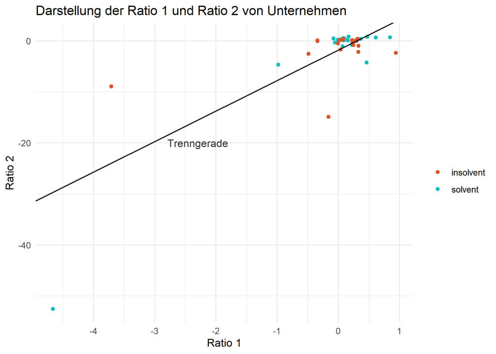

In der Grafik sehen wir für jedes Unternehmen aus unserem Lerndatensatz dessen Ratio1 als Wert der x-Achse und Ratio2 als Wert der y-Achse. Diese Einträge sind zusätzlich noch farblich in insolvente (rot) und solvente (blau) Unternehmen aufgeteilt.

Wir sehen schnell, dass es ein paar wenige Ausreißer gibt, jedoch die meisten Unternehmen eine Ratio1 im Intervall von -0,5 bis 0,5 und eine Ratio2 von ungefähr 0 haben. Ein solventes Unternehmen mit einer Ratio1 von ungefähr -4.5 und einer Ratio2 von ungefähr -52 ist sehr auffällig. Das ist ein Alarmsignal, denn eine derart niedrige Ratio2 bedeutet entweder, dass es sich um einen Fehler handelt, oder dass das Unternehmen seit längerer Zeit Verluste gemacht hat und gefährdet ist insolvent zu gehen. Eine negative Ratio1, wie bei diesem (und noch einem anderen) Unternehmen beobachtet, ist ein Zeichen dafür, dass viel kurzfristiges Fremdkapital im Unternehmen ist. Das ist nicht weiter dramatisch, falls man bald mit Zahlungseingang rechnen kann.

Nachdem Sie sich ein Bild Ihrer Diskriminanzanalyse gemacht haben, können Sie die Klassifikationsgüte Ihres Modells auch anhand einer Tabelle verdeutlichen.

13. Erstellen Sie eine Tabelle, in der Sie die vom Modell vorhergesagten Zugehörigkeit zu “solvent” bzw. “insolvent” dem tatsächlichen Status “solvent” bzw. “insolvent” gegenüberstellen.
- In wie viel Prozent der Fälle lagen Sie mit ihrem Modell richtig?
  - Beschreiben und interpretieren Sie ihre Tabelle

Informationen zur vorhergesagten und tatsächlichen Solvenz/Insolvenz der Unternehmen

| Tatsächliche Gruppenzugehörigkeit | Vorhergesagte Gruppenzugehörigkeit insolvent | Vorhergesagte Gruppenzugehörigkeit solvent |
| --- | --- | --- |
| insolvent | 6 | 14 |
| solvent | 7 | 13 |

| Anteil der Fälle in denen das Modell richtig lag (in Prozent) |
| --- |
| 47.5 |

In der Tabelle sehen wir zu allen insolventen und zu allen solventen Firmen des Lerndatensatzes die Anzahl an denen der tatsächliche Status als insolvent und an denen er als solvent vorhergesagt wurde. Bei den 20 tatsächlich insolventen Unternehmen wurden 6 Unternehmen korrekt als insolvent vorhergesagt, doch der überwiegende Großteil (14) fälschlicherweise als solvent. Bei den solventen Unternehmen sieht das schon besser aus. Hier wurden 13 der 20 korrekt als solvent vorhergesagt und nur 7 als insolvent. Es fällt hier stark auf, dass unser Modell wohl eher dazu tendiert, Unternehmen als solvent einzustufen. Die Vorhersage als insolvent kommt (selbst bei den tatsächlich insolventen Unternehmen) nur ungefähr halb so oft vor.

Wir haben nun den Anteil der Fälle ausgerechnet, bei denen unser Modell den tatsächlichen Status des Unternehmens korrekt vorhergesagt hat und kamen auf 47,5%. Da dieser Wert sogar unter 50% liegt, ist das Ergebnis enttäuschend und unser Modell hat nicht wirklich gut funktioniert. Allein anhand unserer Vorhersage kann man sich also definitiv nicht sicher sein über den Status eines Unternehmens. Man sollte vorallem aufpassen, wenn das Unternehmen als solvent vorhergesagt wird.

## Diskriminanzanalyse mit dem Testdatensatz

Arbeiten Sie im folgenden Kapitel ausschließlich mit dem `testdatensatz`.

14. Berechnen Sie auf Basis der von Ihnen berechneten Diskriminanzkoeffizienten $ß_{i}$ die Diskriminanzwerte $Z$ im `testdatensatz`.

*Hinweis:* D.h. hier müssen Sie keine neuen $ß$s mehr berechnen, sondern können einfach die zuvor berechneten Werte für $ß_1$ und $ß_2$ heranziehen!

15. Erstellen Sie ein Streudiagramm, analog zu Aufgabe 12, nur diesmal für den `testdatensatz` (incl. Trenngerade).
- Beschreiben und interpretieren Sie ihre Grafik. Gehen Sie hierbei insbesondere auf die Unterschiede zur Grafik aus Aufgabe 12 ein.
  - Wie würden Sie die Trennschärfe im Testdatensatz bewerten?

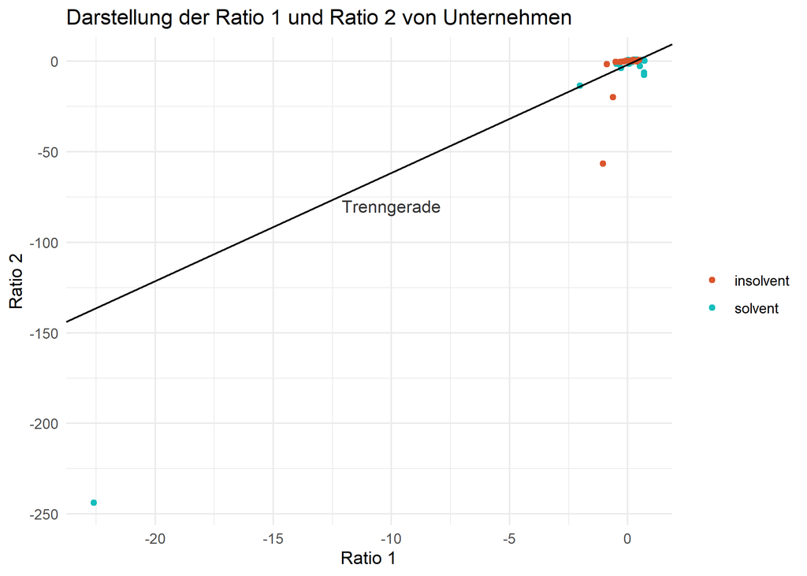

In der Grafik sehen wir für jedes Unternehmen aus unserem Testdatensatz dessen Ratio1 als Wert der x-Achse und Ratio2 als Wert der y-Achse. Diese Einträge sind zusätzlich noch farblich in insolvente (rot) und solvente (blau) Unternehmen aufgeteilt.

Wir sehen wieder, dass es ein paar wenige Ausreißer gibt, jedoch die meisten Unternehmen eine Ratio1 im Intervall von -0,5 bis 0,5 und eine Ratio2 von ungefähr 0 haben, wie beim Lerndatensatz. Erneut fällt ein solventes Unternehmen mit einer Ratio1 von ungefähr -22 und einer Ratio2 von ungefähr -240 auf. Diesmal sind die Werte noch schlechter und extremer als beim Lerndatensatz. Eine derart niedrige Ratio2 bedeutet, dass das Unternehmen entweder eine Fehlangabe gemacht hat oder seit längerer Zeit Verluste gemacht hat und gefährdet ist insolvent zu gehen, noch stärker als im Lerndatensatz.

16. Erstellen Sie auf dem `testdatensatz` analog zu Aufgabe 13 eine Tabelle, in der Sie die vom Modell vorhergesagten Zugehörigkeit zu “solvent” bzw. “insolvent” dem tatsächlichen Status “solvent” bzw. “insolvent” gegenüberstellen.
- In wie viel Prozent der Fälle lagen Sie mit ihrem Modell richtig?
  - Beschreiben und interpretieren Sie ihre Tabelle

Informationen zur vorhergesagten und tatsächlichen Solvenz/Insolvenz der Unternehmen

| Tatsächliche Gruppenzugehörigkeit | Vorhergesagte Gruppenzugehörigkeit insolvent | Vorhergesagte Gruppenzugehörigkeit solvent |
| --- | --- | --- |
| insolvent | 4 | 16 |
| solvent | 8 | 12 |

| Anteil der Fälle in denen das Modell richtig lag (in Prozent) |
| --- |
| 40 |

In der Tabelle sehen wir zu allen insolventen und zu allen solventen Firmen des Testdatensatzes die Anzahl an denen der tatsächliche Status als insolvent und an denen er als solvent vorhergesagt wurde. Bei den 20 tatsächlich insolventen Unternehmen wurden diesmal nur 4 Unternehmen korrekt als insolvent vorhergesagt und der Großteil (16) wieder fälschlicherweise als solvent. Dies ist noch schlechter als beim Lerndatensatz. Bei den solventen Unternehmen sieht das erneut etwas besser aus. Hier wurden 12 der 20 korrekt als solvent vorhergesagt und nur 8 als insolvent. Dies hat sich jedoch zum Lerndatensatz auch um 1 Unternehmen verschlechtert. Es fällt erneut auf, dass unser Modell dazu tendiert, Unternehmen als solvent einzustufen. 28 der 40 Unternehmen wurden als solvent vorhergesagt, obwohl nur 20 davon wirklich solvent sind.

Wir haben nun wieder den Anteil der Fälle ausgerechnet, bei denen unser Modell den tatsächlichen Status des Unternehmens korrekt vorhergesagt hat und kamen auf 40%, was (wie schon bei der Grafik und der Tabelle erwartet) kleiner als beim Lerndatensatz ist. Hier schneidet unser Modell also noch schlechter ab.

17. Warum ist eine Unterteilung ihres Datensatzes in Lerndatensatz und Testdatensatz bei Prognosen sinnvoll?
- Nutzen Sie die Erkenntnisse aus ihrer eigenen Analyse für die Antwort auf diese Frage.

Man kann gut von einem ersten Lerndatensatz lernen, in dem man schaut, wo das Modell fehlerhaft und ungenau war. Durch diese Erkenntnis kann man dann beim Testdatensatz Fehler vermeiden oder zumindest reduzieren. Wir haben hier schon beim Lerndatensatz festgestellt, dass das Modell mit einer Genauigkeit von unter 50% bei der Feststellung des Status des Unternehmens eher schlecht abschneidet. Daraufhin hätte man für den Testdatensatz ein anderes Modell wählen können. Der Hauptgrund ist jedoch, dass man den Lerndatensatz nutzt, um die kritische Diskriminanz zu bestimmen, anhand der man dann am Testdatensatz Vorhersagen machen kann. Dieser Wert wurde somit auf Daten angewendet, die nichts mit ihm zu tun haben. Der Testdatensatz hat eigentlich nichts mit der kritischen Diskriminanz zu tun und man kann dadurch den Status der Unternehmen unabhängig vom Datensatz vorhersagen und schauen, ob die Prognose gut oder schlecht war. Man kann die kritische Diskriminanz am Testdatensatz quasi testen und schauen wie gut sie als Prognose-Werkzeug abschneidet. Anhand dessen kann man sehen wie gut sie für andere Datensätze geeignet ist.

18. In dieser Arbeit haben Sie zwei unterschiedliche Gruppen betrachtet. Konkret haben Sie eine sogenannte Treatment Gruppe (“Insolvent”) mit einer Kontrollgruppe (“Solvent”) verglichen und Unterschiede der beiden Gruppen aufgezeigt. Worin liegt das größte Problem bei derartigen Studien, wenn die Gruppen im nachhinein festgelegt wurden, d.h. wenn die Information zu “Solvent” und “Insolvent” bei der Gruppenauswahl bereits bekannt sind?

Die Diskriminanzanalyse basiert auf dem Wissen des echten Status der Unternehmen. Bei der Berechnung der Variablen wird schon in solvent und insolvent unterteilt, wofür man wissen muss, welche Unternehmen solvent und insolvent sind. Somit ist die ganze Analyse durch diese Einteilung beeinflusst. Das was wir nun also nicht mehr machen, ist, die Unternehmen unvoreingenommen zu betrachten und nur anhand ihrer wirtschaftlichen Kennzahlen zu analysieren und als solvent/insolvent einzustufen. Das Problem daran ist, dass eine Insolvenz verschiedene Gründe haben kann ((drohende) Zahlungsunfähigkeit, Überschuldung). Diese verschiedenen Gründe bedeuten, dass auch die Kennzahlen verschieden sind (andere Kennzahlen bei Zahlungsfähigkeit als bei Überschuldung). Diese Unterschiede werden jedoch von uns nicht berücksichtigt und durch die Diskriminanzanalyse werden quasi alle insolventen Unternehmen “in einen Topf geworfen”. Die Analyse führt man dann anhand dieser “vermischten” Kennzahlen durch, wobei einige Unternehmen falsch eingeschätzt werden. Besser wäre es, wenn man die Insolvenzgründe genauer in den Daten erkennbar machen würde.

Außerdem ist ein grundlegendes Problem bei dieser Art von Analyse, dass wir gleich viele solvente und insolvente Firmen in unseren Daten haben und nicht einen Anteil wie er bei der Grundgesamtheit zu erwarten wäre. Dadurch, dass die insolventen Unternehmen in den Stichproben überrepräsentiert sind, wird das Ergebnis der Analyse verzerrt. In unserem Anfangsdatensatz (calculations) waren es 95 solvente und 45 insolvente Unternehmen. In der neuen Aufteilung mit 20 solventen und 20 insolventen sind somit die solventen Unternehmen unterrepräsentiert und die insolventen überrepräsentiert. Da es sich bei unserem Modell um ein Quasi-Experiment handelt ist hier somit keine randomisierte Stichprobe erfolgt. Durch diese feste Zuteilung ist keine Kontrolle der Störvariablen möglich (geringe interne Validität), welche aber das Ergebnis beeinflussen. Dadurch verliert unser Experiment an Aussagekraft und Sicherheit.

# Zusatzaufgabe

Sie haben sich in dieser Projektausarbeitung mit der Diskriminanzanalyse nach Altman (1968) beschäftigt und sich zwei wichtige Faktoren (Ratios) für die Insolvenzprognose herausgegriffen. Altman (1968) hat jedoch insgesamt 5 verschiedene Ratios in seiner Analyse identifiziert, welche auch noch heute häufig verwendet werden.

In dieser Zusatzaufgabe sollen Sie sich den Effekt von allen 5 Ratios zusammen anschauen. Hierfür sollten Sie sich noch die zusätzlichen Variablen aus den Excel-Sheets “Active_additional” und “Dead_additional” in R einlesen und damit arbeiten.

- Lesen Sie die Excel-Sheets “Active_additional” und “Dead_additional” aus dem Excel-File “Diskriminanzanalyse.xlsx” im Ordner “data” ein und bringen diese in die gewünschte Form, wie in Aufgabe 2 - 4 erläutert
- “Joinen” Sie diese Informationen anhand von `dscode`, `jahr` und `default` zu ihrem `testdatensatz`
- Berechnen Sie sich die folgenden Ratios:

$$Ratio_3 = Earnings\ before\ interest\ and\ taxes / Total\ Assets$$
$$Ratio_4 = Market\ value / Total\ Liabilities$$

$$Ratio_5 = Sales / Total\ Assets$$

- Nutzen Sie die von Altman berechneten $ß$s ( $1.2 * Ratio_1 + 1.4 * Ratio_2 + 3.3 * Ratio_3 + 0.6 * Ratio_4 + 0.999 * Ratio_5$ ) und berechnen Sie die Diskriminanzwerte $Z$ für alle ihre Firmen im `testdatensatz`
- Erstellen Sie analog zu Aufgabe 16 eine Tabelle in der Sie die vom Modell vorhergesagten Zugehörigkeit zu “solvent” bzw. “insolvent” dem tatsächlichen Status “solvent” bzw. “insolvent” gegenüberstellen; nehmen Sie als kritischen Diskriminanzwert $Z$ = 1.8 an.

Beschreiben und interpretieren Sie ihre Tabelle. Können Sie mehr/weniger/gleich viele Unternehmen in die “richtig” Kategorie eingruppieren mit allen Ratios und Altmans $ß$s?

*Hinweis:* Beachten Sie, das es zwei `-` in der Variable `Name` für die Ausprägung “Unternehmensname - Net Income - Basic” gibt (weiterin enthalten drei Unternehmen in ihrem Unternehmensnamen ein `-`)

Informationen zur vorhergesagten und tatsächlichen Solvenz/Insolvenz der Unternehmen

| Tatsächliche Gruppenzugehörigkeit | Vorhergesagte Gruppenzugehörigkeit insolvent | Vorhergesagte Gruppenzugehörigkeit solvent |
| --- | --- | --- |
| solvent | 6 | 13 |

| Anteil der Fälle in denen das Modell richtig lag (in Prozent) |
| --- |
| 68.42 |

In der Tabelle sehen wir zu allen insolventen und zu allen solventen Firmen des Testdatensatzes die Anzahl an denen der tatsächliche Status als insolvent und an denen er als solvent vorhergesagt wurde. Benutzt haben wir diesmal alle 5 Ratios von Altman. Da bei vielen Firmen aus unserem Testset wegen fehlenden Daten die Altman-Zusatzwerte nicht vorliegen, haben wir hier nur lediglich 19 solvente Firmen betrachtet. Bei 13 dieser Unternehmen wurde der Status richtig als solvent vorhergesagt. 6 wurden jedoch fälschlicherweise als insolvent vorhergesagt.

Wir haben auch hier den Anteil der Fälle ausgerechnet, bei denen unser Modell den tatsächlichen Status des Unternehmens korrekt vorhergesagt hat und kamen auf 68,42%, was, wie schon erwartet, definitiv höher ist als bei der Analyse mit den 2 Ratios und eigenen Betas. Das Problem hierbei scheint die Datenermittlung zu sein, weswegen wir hier nur 19 Unternehmen betrachten konnten. Zu den Restlichen gab es nicht genug Daten um alle 5 Ratios zu bestimmen. Dadurch können wir nur sehen wie das Modell auf solvente Unternehmen reagiert. Über insolvente haben wir keine Informationen. Bei solventen Unternehmen schnitt das Modell jedoch auch schon mit nur 2 Ratios und eigenen Betas gut ab. Hier lag der Anteil der korrekten Vorhersagen beim Lerndatensatz bei 65% und beim Testdatensatz bei 60%. Dieser Anteil ist zwar bei dem Modell mit 5 Ratios etwas besser, jedoch brauchen wir Daten zu den insolventen Unternehmen, um sagen zu können ob das Modell an sich besser ist. Diese ziehen nämlich die Treffsicherheit bei dem Modell mit 2 Ratios in beiden Datensätzen erheblich nach unten.

# Literatur

Altman, E. I. (1968). Financial ratios, discriminant analysis and the prediction of corporate bankruptcy. The journal of finance, 23(4), 589-609.

# Anhang

## Diskriminanzanalyse

In der Diskriminanzanalyse geht es darum, zwei (oder mehr) unterschiedliche Gruppen möglichst gut voneinander zu trennen. Die Diskriminanzfunktion
$$\begin{equation}
Z = \beta_1 X_1 + \beta_2 X_2
\end{equation}$$

soll hierfür maximiert werden. Dafür sollen die Koeffizienten $\beta_i$ in der Diskriminanzfunktion so gebildet werden, dass die beiden Gruppen sich maximal voneinander unterschieden. In unserem Fall (zwei Gruppen und zwei Kennzahlen) ergibt sich bei der Maximierung der Diskriminanzfunktion folgende Formel für die Diskriminanzkoeffizienten:

$$\begin{equation}
\beta_1 = \frac{d_2 S_{12} - d_1 S_{22}}{S_{12}^2-S_{11}S_{22}} \, \, \, \, \, \, \, \,
\beta_2 = \frac{d_1 S_{12} - d_2 S_{11}}{S_{12}^2-S_{11}S_{22}}
\end{equation}$$

Dabei sind die jeweiligen Variablen wie folgt definiert:

- $d_m = \bar{X}_{m,solvent} - \bar{X}_{m,insolvent}$

-> *Differenz der Mittelwerte pro Gruppe pro Kennzahl m*, mit *n* als Anzahl der Unternehmen in jeder Gruppe (solvent vs. insolvent), mit

$$\begin{equation}
X_{m,(in-)solvent} = (x_{1,m,(in-)solvent} \dots x_{n,m,insolvent})
\end{equation}$$
$$\begin{equation}
\bar{X}_{m,solvent} = \frac{1}{n} \sum_{i=1}^n x_{i,m,solvent}
\end{equation}$$
$$\begin{equation}
\bar{X}_{m,insolvent} = \frac{1}{n} \sum_{i=1}^n x_{i,m,insolvent}
\end{equation}$$

- $S_{mm} = \sum_{i=1}^n (x_{i,m,solvent} - \bar{X}_{m,solvent})^2 + \sum_{i=1}^n (x_{i,m,insolvent} - \bar{X}_{m,insolvent})^2$

-> Summe der *gruppeninternen Abweichungsquadrate* der Kennzahl *m*

- $S_{mk} = \sum_{i=1}^n (x_{i,m,solvent} - \bar{X}_{m,solvent}) \times (x_{i,k,solvent} - \bar{X}_{k,solvent}) + \\ \sum_{i=1}^n (x_{i,m,insolvent} - \bar{X}_{m,insolvent}) \times (x_{i,k,insolvent} - \bar{X}_{k,insolvent})$

-> Summe der *gruppeninternen Abweichungsprodukte* der beiden Kennzahlen *m* und *k*

Der kritische Diskriminanzwert $\bar{Z}$ stellt genau den Trennpunkt dar, der die jeweiligen Unternehmen in die beiden Gruppen solvent oder insolvent klassifiziert. Dieser ergibt sich als Mittelwert aller Diskriminanzwerte über beide Gruppen hinweg.